# Análise de Regressão - LaLiga e Ligue1

Author

Gustavo e Pedro

```r
library(tidyverse)
library(corrplot)
library(ggcorrplot)
```

# Análise de regressão LaLiga

Vamos, primeiramente, ler os dados ue coletamos sobre a LaLiga:

```r
dadosLaLiga = read_csv("dados_campeoes_LaLiga.csv")

dadosLaLiga |>
  head()
```

```
# A tibble: 6 × 20
    ano campeao  parti…¹ vitor…² empat…³ derro…⁴ gols_…⁵ gols_…⁶ saldo…⁷ ponto…⁸
  <dbl> <chr>      <dbl>   <dbl>   <dbl>   <dbl>   <dbl>   <dbl>   <dbl>   <dbl>
1  2000 Dep. La…      38      21       6      11      66      44      22      69
2  2001 Real Ma…      38      24       8       6      81      40      41      80
3  2002 Valencia      38      21      12       5      51      27      24      75
4  2003 Real Ma…      38      22      12       4      86      42      44      78
5  2004 Valencia      38      23       8       7      71      27      44      77
6  2005 Barcelo…      38      25       9       4      73      29      44      84
# … with 10 more variables: numero_times <dbl>, total_gols <dbl>,
#   media_gols <dbl>, aproveitamento <dbl>, cidade <chr>, estadio <lgl>,
#   campeao_ano_anterior <lgl>, ano_copa_do_mundo <lgl>, ano_eurocopa <lgl>,
#   espanha_times_final_champions <dbl>, and abbreviated variable names
#   ¹partidas_campeao, ²vitorias_campeao, ³empates_campeao, ⁴derrotas_campeao,
#   ⁵gols_pro_campeao, ⁶gols_contra_campeao, ⁷saldo_campeao, ⁸pontos_campeao
```

Vamos conferir se todas as variáveis foram lidas corretamente:

```r
dadosLaLiga |>
  glimpse()
```

```
Rows: 23
Columns: 20
$ ano                           <dbl> 2000, 2001, 2002, 2003, 2004, 2005, 2006…
$ campeao                       <chr> "Dep. La Coruña", "Real Madrid", "Valenc…
$ partidas_campeao              <dbl> 38, 38, 38, 38, 38, 38, 38, 38, 38, 38, …
$ vitorias_campeao              <dbl> 21, 24, 21, 22, 23, 25, 25, 23, 27, 27, …
$ empates_campeao               <dbl> 6, 8, 12, 12, 8, 9, 7, 7, 4, 6, 6, 6, 4,…
$ derrotas_campeao              <dbl> 11, 6, 5, 4, 7, 4, 6, 8, 7, 5, 1, 2, 2, …
$ gols_pro_campeao              <dbl> 66, 81, 51, 86, 71, 73, 80, 66, 84, 105,…
$ gols_contra_campeao           <dbl> 44, 40, 27, 42, 27, 29, 35, 40, 36, 35, …
$ saldo_campeao                 <dbl> 22, 41, 24, 44, 44, 44, 45, 26, 48, 70, …
$ pontos_campeao                <dbl> 69, 80, 75, 78, 77, 84, 82, 76, 85, 87, …
$ numero_times                  <dbl> 20, 20, 20, 20, 20, 20, 20, 20, 20, 20, …
$ total_gols                    <dbl> 999, 1095, 961, 1016, 1015, 980, 936, 94…
$ media_gols                    <dbl> 2.628947, 2.881579, 2.528947, 2.673684, …
$ aproveitamento                <dbl> 60.52632, 70.17544, 65.78947, 68.42105, …
$ cidade                        <chr> "Coruña", "Madrid", "Valencia", "Madrid"…
$ estadio                       <lgl> FALSE, TRUE, TRUE, TRUE, TRUE, TRUE, TRU…
$ campeao_ano_anterior          <lgl> FALSE, FALSE, FALSE, FALSE, FALSE, FALSE…
$ ano_copa_do_mundo             <lgl> FALSE, FALSE, TRUE, FALSE, FALSE, FALSE,…
$ ano_eurocopa                  <lgl> TRUE, FALSE, FALSE, FALSE, TRUE, FALSE, …
$ espanha_times_final_champions <dbl> 2, 1, 1, 0, 0, 0, 1, 0, 0, 1, 0, 1, 0, 0…
```

## Análise variávies

Vamos analisar as variáveis que podemos utilizar a fim de explicar o aproveitamento do campeão. Dessa forma, não podemos utilizar as variáveis específicas de cada ano, como o próprio ano e o campeão, verificar as variáveis com variância 0 e retirar as variáveis que estão diretamente ligadas ao aproveitamento:

```r
(variancias = dadosLaLiga |>
  select_if(is.numeric) |>
  apply(2, var))
```

```
                          ano              partidas_campeao
                 4.600000e+01                  0.000000e+00
             vitorias_campeao               empates_campeao
                 1.089328e+01                  5.498024e+00
             derrotas_campeao              gols_pro_campeao
                 5.612648e+00                  3.490830e+02
          gols_contra_campeao                 saldo_campeao
                 4.931621e+01                  3.949368e+02
               pontos_campeao                  numero_times
                 7.120158e+01                  0.000000e+00
                   total_gols                    media_gols
                 2.930810e+03                  2.029647e-02
               aproveitamento espanha_times_final_champions
                 5.478730e+01                  5.098814e-01
```

Podemos ver que as variáveis de número de times e número de partidas tem variância zero, logo não podemos utilizá-las no modelo:

```r
colunas_ligadas_y = c("vitorias_campeao", "empates_campeao",
                      "derrotas_campeao", "pontos_campeao")
colunas_var_0 = variancias[variancias == 0] |>
  names()
colunas_especificas = c("campeao", "ano")

dados_regressao_LaLiga = dadosLaLiga |>
  select(-!!colunas_ligadas_y, -!!colunas_especificas, -!!colunas_var_0)

dados_regressao_LaLiga |>
  glimpse()
```

```
Rows: 23
Columns: 12
$ gols_pro_campeao              <dbl> 66, 81, 51, 86, 71, 73, 80, 66, 84, 105,…
$ gols_contra_campeao           <dbl> 44, 40, 27, 42, 27, 29, 35, 40, 36, 35, …
$ saldo_campeao                 <dbl> 22, 41, 24, 44, 44, 44, 45, 26, 48, 70, …
$ total_gols                    <dbl> 999, 1095, 961, 1016, 1015, 980, 936, 94…
$ media_gols                    <dbl> 2.628947, 2.881579, 2.528947, 2.673684, …
$ aproveitamento                <dbl> 60.52632, 70.17544, 65.78947, 68.42105, …
$ cidade                        <chr> "Coruña", "Madrid", "Valencia", "Madrid"…
$ estadio                       <lgl> FALSE, TRUE, TRUE, TRUE, TRUE, TRUE, TRU…
$ campeao_ano_anterior          <lgl> FALSE, FALSE, FALSE, FALSE, FALSE, FALSE…
$ ano_copa_do_mundo             <lgl> FALSE, FALSE, TRUE, FALSE, FALSE, FALSE,…
$ ano_eurocopa                  <lgl> TRUE, FALSE, FALSE, FALSE, TRUE, FALSE, …
$ espanha_times_final_champions <dbl> 2, 1, 1, 0, 0, 0, 1, 0, 0, 1, 0, 1, 0, 0…
```

## Análise correlações

Agora, vamos realizar uma análise de correlações:

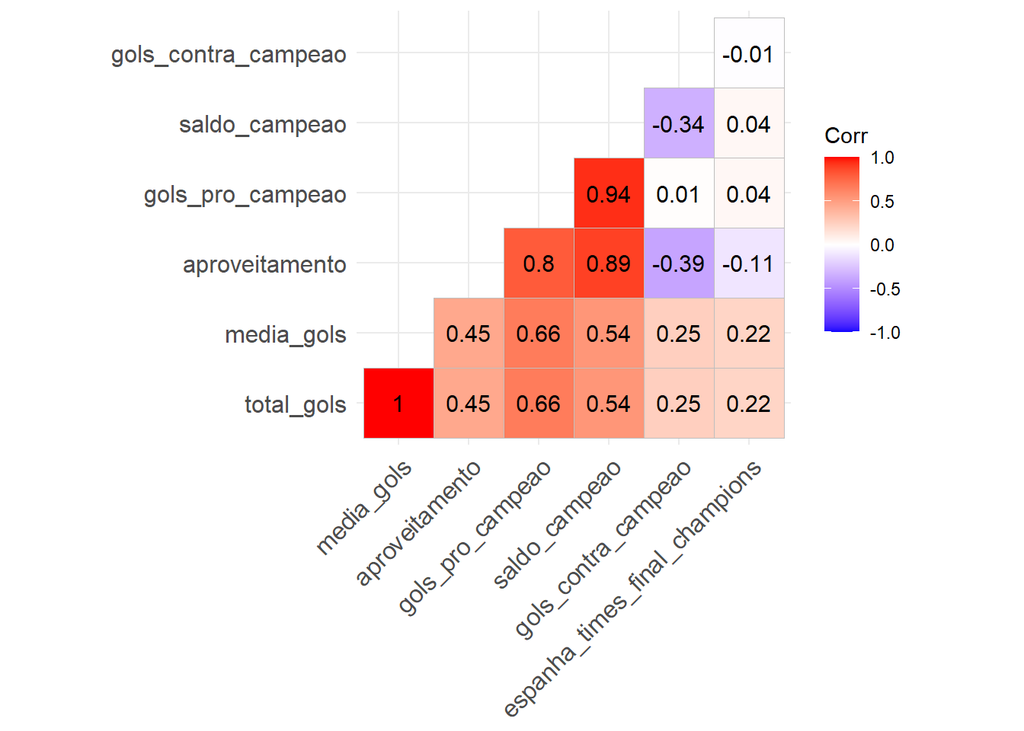

```r
dados_regressao_LaLiga |>
  select_if(is.numeric) |>
  cor() |>
  ggcorrplot(hc.order = TRUE, type = "lower", lab = TRUE)
```

Podemos verficar, analisando as variáveis numéricas, que o aproveitamento tem uma correlação forte positiva com o saldo de gols e gols pró, porém essas duas são muito correlacionadas, logo vamos priorizar utilizar o saldo de gols que tem uma correlação maior com a variável de interesse. Vamos utilizar a variável de `gols_contra_campeao` que apresenta uma correlação negativa média.

Além disso, vemos que a correlação entre total de gols e média de gols foi 1(isso ocorre pois em todos os anos tivemos a mesma quantidade de partidas).

## Análise variáveis categóricas

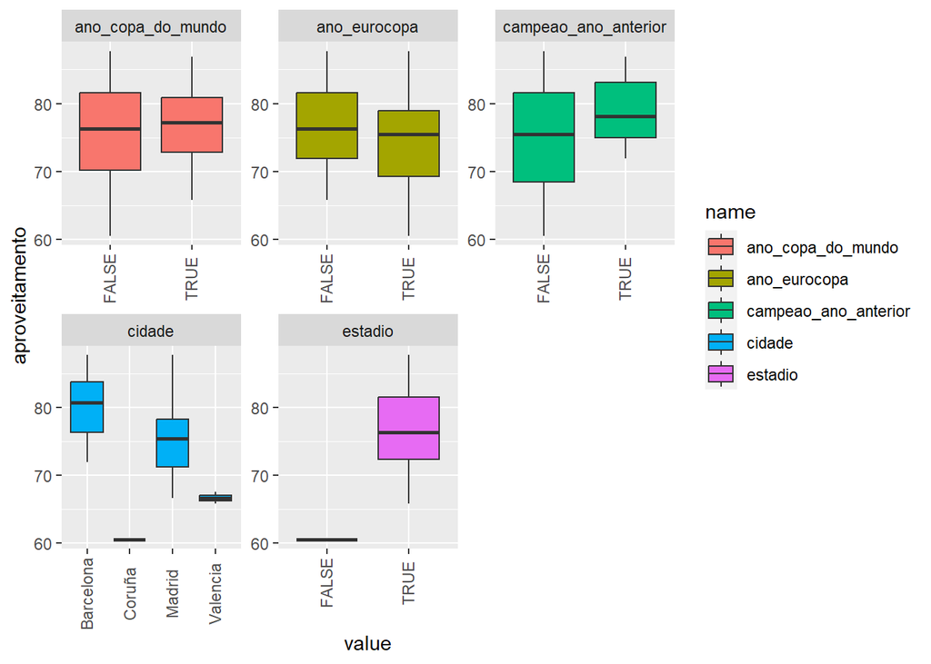

```r
dados_regressao_LaLiga |>
  select(where(is.logical), where(is.character), aproveitamento) |>
  mutate(across(!aproveitamento, as.character)) |>
  pivot_longer(-aproveitamento) |>
  ggplot() +
  aes(x = value, y = aproveitamento, fill = name) +
  facet_wrap(~name, scales = "free") +
  geom_boxplot() +
  theme(
    axis.text.x = element_text(angle = 90, vjust = 0.4, hjust = 0.5)
  )
```

Analisando as variáveis, podemos ver que as variáveis se o ano é de Copa do Mundo ou Eurocopa, aparentemente, não tem uma relação clara. Em relação a variável se foi campeão ano anterior, temos uma diferença porém não tão clara do aproveitamento, dessa forma vamos ajustar o modelo com essa variável e verificar o resultado.

Agora as variáveis de cidade e tem tem estadio próprio tem uma diferença muito grande do aproveitamento entre as classes. No entanto, temos apenas uma observação que um time sem estádio próprio foi campeão, logo vamos optar por utilizar apenas a variável de cidade.

## Análise de regressão

```r
dados_regressao_LaLiga |>
  glimpse()
```

```
Rows: 23
Columns: 12
$ gols_pro_campeao              <dbl> 66, 81, 51, 86, 71, 73, 80, 66, 84, 105,…
$ gols_contra_campeao           <dbl> 44, 40, 27, 42, 27, 29, 35, 40, 36, 35, …
$ saldo_campeao                 <dbl> 22, 41, 24, 44, 44, 44, 45, 26, 48, 70, …
$ total_gols                    <dbl> 999, 1095, 961, 1016, 1015, 980, 936, 94…
$ media_gols                    <dbl> 2.628947, 2.881579, 2.528947, 2.673684, …
$ aproveitamento                <dbl> 60.52632, 70.17544, 65.78947, 68.42105, …
$ cidade                        <chr> "Coruña", "Madrid", "Valencia", "Madrid"…
$ estadio                       <lgl> FALSE, TRUE, TRUE, TRUE, TRUE, TRUE, TRU…
$ campeao_ano_anterior          <lgl> FALSE, FALSE, FALSE, FALSE, FALSE, FALSE…
$ ano_copa_do_mundo             <lgl> FALSE, FALSE, TRUE, FALSE, FALSE, FALSE,…
$ ano_eurocopa                  <lgl> TRUE, FALSE, FALSE, FALSE, TRUE, FALSE, …
$ espanha_times_final_champions <dbl> 2, 1, 1, 0, 0, 0, 1, 0, 0, 1, 0, 1, 0, 0…
```

```r
modelo_reg_LaLiga = lm(
  aproveitamento ~ saldo_campeao + gols_contra_campeao + cidade + campeao_ano_anterior,
  dados_regressao_LaLiga
  )
```

### Anova

A fim de analisar as variáveis do modelo vamos realizar uma análise de variância:

```r
modelo_reg_LaLiga |>
  anova()
```

```
Analysis of Variance Table

Response: aproveitamento
                     Df Sum Sq Mean Sq F value    Pr(>F)
saldo_campeao         1 963.13  963.13 87.8787 6.697e-08 ***
gols_contra_campeao   1   9.87    9.87  0.9009    0.3567
cidade                3  56.88   18.96  1.7301    0.2011
campeao_ano_anterior  1   0.08    0.08  0.0072    0.9335
Residuals            16 175.36   10.96
---
Signif. codes:  0 '***' 0.001 '**' 0.01 '*' 0.05 '.' 0.1 ' ' 1
```

Pelo teste $F$, podemos verificar que rejeitamos a hipótese nula de todos os coeficientes sejam igual a 0. Onde apenas para a variável de saldo de gols foi significativa.

### Teste t

```r
modelo_reg_LaLiga |>
  summary()
```

```
Call:
lm(formula = aproveitamento ~ saldo_campeao + gols_contra_campeao +
    cidade + campeao_ano_anterior, data = dados_regressao_LaLiga)

Residuals:
    Min      1Q  Median      3Q     Max
-4.8526 -1.5138  0.3141  0.9942  7.0989

Coefficients:
                         Estimate Std. Error t value Pr(>|t|)
(Intercept)              64.98628    5.77567  11.252  5.2e-09 ***
saldo_campeao             0.28442    0.04949   5.747  3.0e-05 ***
gols_contra_campeao      -0.14244    0.12018  -1.185    0.253
cidadeCoruña             -4.44978    4.37039  -1.018    0.324
cidadeMadrid              1.11810    1.89160   0.591    0.563
cidadeValencia           -4.14407    3.31027  -1.252    0.229
campeao_ano_anteriorTRUE  0.15304    1.80622   0.085    0.934
---
Signif. codes:  0 '***' 0.001 '**' 0.01 '*' 0.05 '.' 0.1 ' ' 1

Residual standard error: 3.311 on 16 degrees of freedom
Multiple R-squared:  0.8545,    Adjusted R-squared:    0.8
F-statistic: 15.66 on 6 and 16 DF,  p-value: 6.848e-06
```

### Modelo apenas com variáveis significativas

Como vimos, apenas a variável de saldo de gols foi significativa. Logo vamos ajustar um modelo apenas com essa variável.

```r
modelo_final_reg_LaLiga = lm(
  aproveitamento ~ saldo_campeao,
  dados_regressao_LaLiga
  )
```

```r
modelo_final_reg_LaLiga |>
  summary()
```

```
Call:
lm(formula = aproveitamento ~ saldo_campeao, data = dados_regressao_LaLiga)

Residuals:
    Min      1Q  Median      3Q     Max
-5.5413 -2.5835  0.5413  2.0236  5.0170

Coefficients:
              Estimate Std. Error t value Pr(>|t|)
(Intercept)   57.73179    2.12974  27.107  < 2e-16 ***
saldo_campeao  0.33294    0.03643   9.138 9.16e-09 ***
---
Signif. codes:  0 '***' 0.001 '**' 0.01 '*' 0.05 '.' 0.1 ' ' 1

Residual standard error: 3.396 on 21 degrees of freedom
Multiple R-squared:  0.7991,    Adjusted R-squared:  0.7895
F-statistic: 83.51 on 1 and 21 DF,  p-value: 9.159e-09
```

A fim de verificar os intervalos de confiança dos coeficientes da regressão vamos utilizar a função `confint`:

```r
confint(modelo_final_reg_LaLiga)
```

```
                   2.5 %     97.5 %
(Intercept)   53.3027548 62.1608234
saldo_campeao  0.2571741  0.4087074
```

A partir do resultados, vemos que o intervalo de 95% de confiança para o intervalo foi de (53,30; 62,16), logo este seria o intervalo para o aproveitamento quando o saldo de gol fosse 0.

Além disso, temos que o intervalo de confiança de 95% para o coeficiente do saldo de gol foi de (0,26; 0,41), logo este seria o aumento do aproveitamento a cada unidade de gol a mais no saldo de gols.

## Intervalo de predição

```r
dados_predicoes_ic = predict(
  modelo_final_reg_LaLiga,
  dados_regressao_LaLiga |>
    select(saldo_campeao),
  interval = "confidence"
  )

dados_predicoes_ic
```

```
        fit      lwr      upr
1  65.05649 62.14622 67.96675
2  71.38236 69.56170 73.20302
3  65.72237 62.94175 68.50298
4  72.38118 70.68419 74.07817
5  72.38118 70.68419 74.07817
6  72.38118 70.68419 74.07817
7  72.71412 71.05348 74.37476
8  66.38825 63.73496 69.04154
9  73.71294 72.14436 75.28153
10 81.03764 79.18349 82.89179
11 82.36940 80.31694 84.42186
12 82.36940 80.31694 84.42186
13 87.36351 84.40482 90.32221
14 82.70234 80.59640 84.80828
15 74.71177 73.20627 76.21727
16 87.36351 84.40482 90.32221
17 85.36587 82.79150 87.94024
18 79.37294 77.72134 81.02454
19 81.03764 79.18349 82.89179
20 75.71059 74.23548 77.18569
21 72.71412 71.05348 74.37476
22 71.71530 69.93813 73.49247
23 74.04589 72.50175 75.59002
```

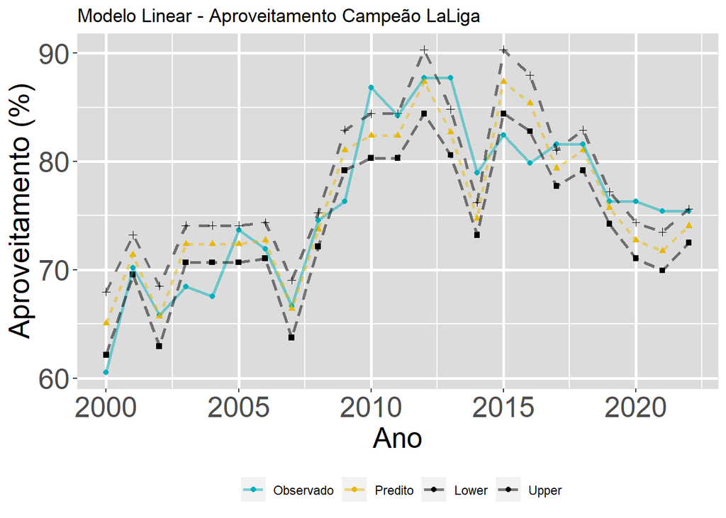

```r
mPred = data.frame(Obs = dadosLaLiga$ano,
                   Observado = dados_regressao_LaLiga$aproveitamento,
                   Predito = dados_predicoes_ic[,1],
                   Lower = dados_predicoes_ic[,2],
                   Upper = dados_predicoes_ic[,3]
                   )

mPred2 = reshape2::melt(mPred, id = "Obs")

ggplot(mPred2, aes(x = Obs, y = value, group = variable)) +
  geom_point(aes(shape = variable, color = variable),
             size = 1.5) +
  geom_line(aes(linetype = variable, color = variable),
            size = 0.9, alpha = 0.5) +
  scale_color_manual(name = "", values = c("#00AFBB", "#E7B800", "black", "black")) +
  guides(shape = "none", linetype = "none") +
  labs(x = "Ano",
       y = "Aproveitamento (%)",
       title = "Modelo Linear - Aproveitamento Campeão LaLiga") +
  theme(legend.title = element_blank(),
        legend.position = "bottom",
        axis.text = element_text(size = 20),
        axis.title = element_text(size = 20),
        panel.background = element_rect(fill = "#DCDCDC",
                                        colour = "#DCDCDC",
                                        size = 0.5, linetype = "solid"),
        panel.grid.major = element_line(size = 0.9, linetype = 'solid',
                                        colour = "white"),
        panel.grid.minor = element_line(size = 0.5, linetype = 'solid',
                                        colour = "white"))
```

A partir do intervalo de predição, vemos que muitas vezes o valor observado está dentro do intervalo, porém ainda temos alguns pontos fora por mais que o intervalo acompanha a tendência dos valores observados.

# Análise de regressão Ligue1

Vamos, primeiramente, ler os dados ue coletamos sobre a Ligue1:

```r
dadosLigue1 = read_csv("dados_campeoes_Ligue1.csv") |>
  group_by(ano)

dadosLigue1 |>
  head()
```

```
# A tibble: 6 × 19
# Groups:   ano [6]
    ano campeao  parti…¹ vitor…² empat…³ derro…⁴ gols_…⁵ gols_…⁶ saldo…⁷ ponto…⁸
  <dbl> <chr>      <dbl>   <dbl>   <dbl>   <dbl>   <dbl>   <dbl>   <dbl>   <dbl>
1  2000 Monaco        34      20       5       9      69      38      31      65
2  2001 FC Nant…      34      21       5       8      58      36      22      68
3  2002 Olympiq…      34      20       6       8      62      32      30      66
4  2003 Olympiq…      38      19      11       8      63      41      22      68
5  2004 Olympiq…      38      24       7       7      64      26      38      79
6  2005 Olympiq…      38      22      13       3      56      22      34      79
# … with 9 more variables: numero_times <dbl>, total_gols <dbl>,
#   media_gols <dbl>, aproveitamento <dbl>, cidade <chr>, estadio <lgl>,
#   campeao_ano_anterior <lgl>, ano_copa_do_mundo <lgl>, ano_eurocopa <lgl>,
#   and abbreviated variable names ¹partidas_campeao, ²vitorias_campeao,
#   ³empates_campeao, ⁴derrotas_campeao, ⁵gols_pro_campeao,
#   ⁶gols_contra_campeao, ⁷saldo_campeao, ⁸pontos_campeao
```

Vamos conferir se todas as variáveis foram lidas corretamente:

```r
dadosLigue1 |>
  glimpse()
```

```
Rows: 23
Columns: 19
Groups: ano [23]
$ ano                  <dbl> 2000, 2001, 2002, 2003, 2004, 2005, 2006, 2007, 2…
$ campeao              <chr> "Monaco", "FC Nantes", "Olympique Lyon", "Olympiq…
$ partidas_campeao     <dbl> 34, 34, 34, 38, 38, 38, 38, 38, 38, 38, 38, 38, 3…
$ vitorias_campeao     <dbl> 20, 21, 20, 19, 24, 22, 25, 24, 24, 24, 23, 21, 2…
$ empates_campeao      <dbl> 5, 5, 6, 11, 7, 13, 9, 9, 7, 8, 9, 13, 7, 8, 8, 1…
$ derrotas_campeao     <dbl> 9, 8, 8, 8, 7, 3, 4, 5, 7, 6, 6, 4, 6, 5, 3, 3, 2…
$ gols_pro_campeao     <dbl> 69, 58, 62, 63, 64, 56, 73, 64, 74, 64, 69, 68, 6…
$ gols_contra_campeao  <dbl> 38, 36, 32, 41, 26, 22, 31, 27, 37, 34, 36, 36, 3…
$ saldo_campeao        <dbl> 31, 22, 30, 22, 38, 34, 42, 37, 37, 30, 33, 32, 3…
$ pontos_campeao       <dbl> 65, 68, 66, 68, 79, 79, 84, 81, 79, 80, 78, 76, 8…
$ numero_times         <dbl> 18, 18, 18, 20, 20, 20, 20, 20, 20, 20, 20, 20, 2…
$ total_gols           <dbl> 787, 765, 716, 837, 884, 826, 811, 858, 868, 858,…
$ media_gols           <dbl> 2.571895, 2.500000, 2.339869, 2.202632, 2.326316,…
$ aproveitamento       <dbl> 63.72549, 66.66667, 64.70588, 59.64912, 69.29825,…
$ cidade               <chr> "Monaco", "Nantes", "Lyon", "Lyon", "Lyon", "Lyon…
$ estadio              <lgl> FALSE, FALSE, TRUE, TRUE, TRUE, TRUE, TRUE, TRUE,…
$ campeao_ano_anterior <lgl> FALSE, FALSE, FALSE, TRUE, TRUE, TRUE, TRUE, TRUE…
$ ano_copa_do_mundo    <lgl> FALSE, FALSE, TRUE, FALSE, FALSE, FALSE, TRUE, FA…
$ ano_eurocopa         <lgl> TRUE, FALSE, FALSE, FALSE, TRUE, FALSE, FALSE, FA…
```

## Análise variávies

Vamos analisar as variáveis que podemos utilizar a fim de explicar o aproveitamento do campeão. Dessa forma, não podemos utilizar as variáveis específicas de cada ano, como o próprio ano e o campeão, verificar as variáveis com variância 0 e retirar as variáveis que estão diretamente ligadas ao aproveitamento:

```r
(variancias = dadosLigue1 |>
  select_if(is.numeric) |>
  apply(2, var))
```

```
                ano    partidas_campeao    vitorias_campeao     empates_campeao
       4.600000e+01        6.636364e+00        1.001976e+01        7.837945e+00
   derrotas_campeao    gols_pro_campeao gols_contra_campeao       saldo_campeao
       4.272727e+00        2.618854e+02        3.887747e+01        3.192688e+02
     pontos_campeao        numero_times          total_gols          media_gols
       8.207905e+01        4.743083e-01        1.004260e+04        3.524037e-02
     aproveitamento
       4.495623e+01
```

Podemos ver que nenhuma das variáveis tem variância zero:

```r
colunas_ligadas_y = c("vitorias_campeao", "empates_campeao",
                      "derrotas_campeao", "pontos_campeao")

colunas_especificas = c("campeao", "ano")

dados_regressao_Ligue1 = dadosLigue1 |>
  ungroup() |>
  select(-!!colunas_ligadas_y, -!!colunas_especificas)

dados_regressao_Ligue1 |>
  glimpse()
```

```
Rows: 23
Columns: 13
$ partidas_campeao     <dbl> 34, 34, 34, 38, 38, 38, 38, 38, 38, 38, 38, 38, 3…
$ gols_pro_campeao     <dbl> 69, 58, 62, 63, 64, 56, 73, 64, 74, 64, 69, 68, 6…
$ gols_contra_campeao  <dbl> 38, 36, 32, 41, 26, 22, 31, 27, 37, 34, 36, 36, 3…
$ saldo_campeao        <dbl> 31, 22, 30, 22, 38, 34, 42, 37, 37, 30, 33, 32, 3…
$ numero_times         <dbl> 18, 18, 18, 20, 20, 20, 20, 20, 20, 20, 20, 20, 2…
$ total_gols           <dbl> 787, 765, 716, 837, 884, 826, 811, 858, 868, 858,…
$ media_gols           <dbl> 2.571895, 2.500000, 2.339869, 2.202632, 2.326316,…
$ aproveitamento       <dbl> 63.72549, 66.66667, 64.70588, 59.64912, 69.29825,…
$ cidade               <chr> "Monaco", "Nantes", "Lyon", "Lyon", "Lyon", "Lyon…
$ estadio              <lgl> FALSE, FALSE, TRUE, TRUE, TRUE, TRUE, TRUE, TRUE,…
$ campeao_ano_anterior <lgl> FALSE, FALSE, FALSE, TRUE, TRUE, TRUE, TRUE, TRUE…
$ ano_copa_do_mundo    <lgl> FALSE, FALSE, TRUE, FALSE, FALSE, FALSE, TRUE, FA…
$ ano_eurocopa         <lgl> TRUE, FALSE, FALSE, FALSE, TRUE, FALSE, FALSE, FA…
```

## Análise correlações

Agora, vamos realizar uma análise de correlações:

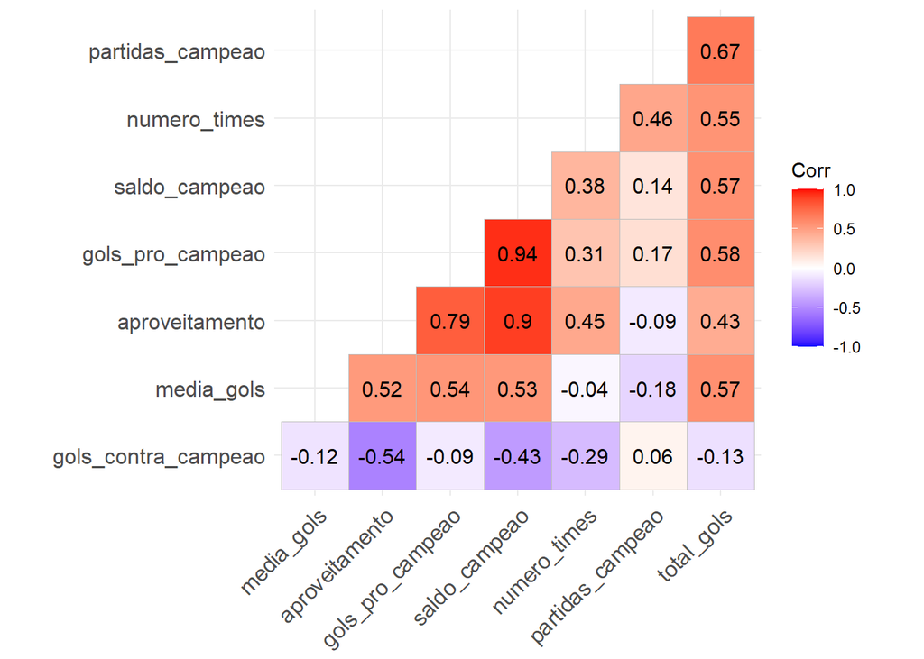

```r
dados_regressao_Ligue1 |>
  select_if(is.numeric) |>
  cor() |>
  ggcorrplot(hc.order = TRUE, type = "lower", lab = TRUE)
```

Podemos verficar, analisando as variáveis numéricas, que o aproveitamento tem uma correlação forte positiva com o saldo de gols e gols pró, porém essas duas são muito correlacionadas, logo vamos priorizar utilizar o saldo de gols que tem uma correlação maior com a variável de interesse.

Além disso, vemos que existe uma correlação média negativa com gols contra. Logo vamos utilizar essa variável no modelo.

## Análise variáveis categóricas

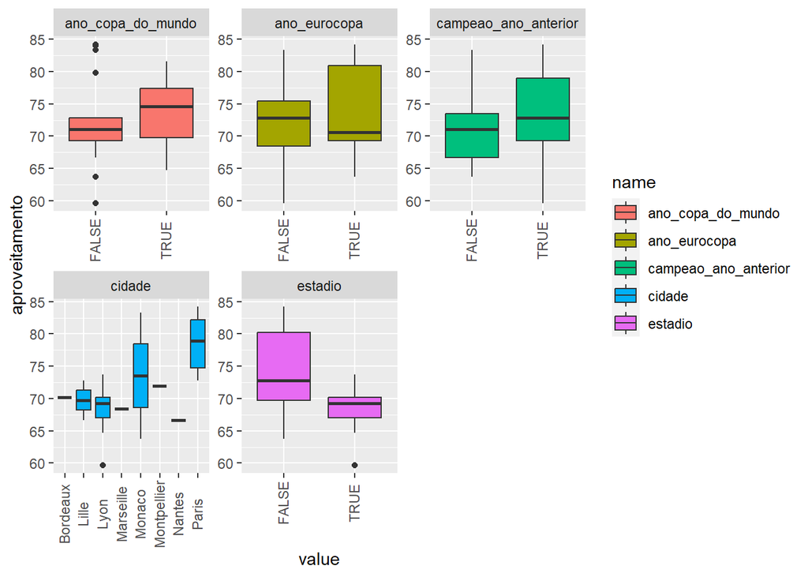

```r
dados_regressao_Ligue1 |>
  select(where(is.logical), where(is.character), aproveitamento) |>
  mutate(across(!aproveitamento, as.character)) |>
  pivot_longer(-aproveitamento) |>
  ggplot() +
  aes(x = value, y = aproveitamento, fill = name) +
  facet_wrap(~name, scales = "free") +
  geom_boxplot() +
  theme(
    axis.text.x = element_text(angle = 90, vjust = 0.4, hjust = 0.5)
  )
```

Analisando as variáveis, podemos ver que as variáveis se o ano é de Copa do Mundo ou Eurocopa, aparentemente, não tem uma relação clara. Em relação a variável se foi campeão ano anterior, temos uma diferença porém não tão clara do aproveitamento, dessa forma vamos ajustar o modelo com essa variável e verificar o resultado.

Em relação as variáveis de cidade e estadio próprio, vemos que sobre a cidade temos várias cidades com apenas uma observação, logo não vamos analisar essa variável. Porém em relação a variável de estadio prório, temos uma relação mais evidente.

## Análise de regressão

```r
dados_regressao_Ligue1 |>
  glimpse()
```

```
Rows: 23
Columns: 13
$ partidas_campeao     <dbl> 34, 34, 34, 38, 38, 38, 38, 38, 38, 38, 38, 38, 3…
$ gols_pro_campeao     <dbl> 69, 58, 62, 63, 64, 56, 73, 64, 74, 64, 69, 68, 6…
$ gols_contra_campeao  <dbl> 38, 36, 32, 41, 26, 22, 31, 27, 37, 34, 36, 36, 3…
$ saldo_campeao        <dbl> 31, 22, 30, 22, 38, 34, 42, 37, 37, 30, 33, 32, 3…
$ numero_times         <dbl> 18, 18, 18, 20, 20, 20, 20, 20, 20, 20, 20, 20, 2…
$ total_gols           <dbl> 787, 765, 716, 837, 884, 826, 811, 858, 868, 858,…
$ media_gols           <dbl> 2.571895, 2.500000, 2.339869, 2.202632, 2.326316,…
$ aproveitamento       <dbl> 63.72549, 66.66667, 64.70588, 59.64912, 69.29825,…
$ cidade               <chr> "Monaco", "Nantes", "Lyon", "Lyon", "Lyon", "Lyon…
$ estadio              <lgl> FALSE, FALSE, TRUE, TRUE, TRUE, TRUE, TRUE, TRUE,…
$ campeao_ano_anterior <lgl> FALSE, FALSE, FALSE, TRUE, TRUE, TRUE, TRUE, TRUE…
$ ano_copa_do_mundo    <lgl> FALSE, FALSE, TRUE, FALSE, FALSE, FALSE, TRUE, FA…
$ ano_eurocopa         <lgl> TRUE, FALSE, FALSE, FALSE, TRUE, FALSE, FALSE, FA…
```

Pelo que analisamos vamos ajustar um modelo de regressão linear com as variáveis `saldo_campeao`, `gols_contra_campeao`, `estadio` e `campeao_ano_anterior`:

```r
modelo_reg_Ligue1 = lm(
  aproveitamento ~ saldo_campeao+gols_contra_campeao+campeao_ano_anterior+estadio,
  dados_regressao_Ligue1
  )
```

### Anova

A fim de analisar as variáveis do modelo vamos realizar uma análise de variância:

```r
modelo_reg_Ligue1 |>
  anova()
```

```
Analysis of Variance Table

Response: aproveitamento
                     Df Sum Sq Mean Sq  F value    Pr(>F)
saldo_campeao         1 808.95  808.95 115.8915 2.838e-09 ***
gols_contra_campeao   1  26.92   26.92   3.8562   0.06520 .
campeao_ano_anterior  1   0.00    0.00   0.0001   0.99041
estadio               1  27.52   27.52   3.9429   0.06252 .
Residuals            18 125.64    6.98
---
Signif. codes:  0 '***' 0.001 '**' 0.01 '*' 0.05 '.' 0.1 ' ' 1
```

Pelo teste $F$, podemos verificar que rejeitamos a hipótese nula de todos os coeficientes sejam igual a 0. Onde apenas para a variável de saldo de gols foi significativa.

### Teste t

```r
modelo_reg_Ligue1 |>
  summary()
```

```
Call:
lm(formula = aproveitamento ~ saldo_campeao + gols_contra_campeao +
    campeao_ano_anterior + estadio, data = dados_regressao_Ligue1)

Residuals:
    Min      1Q  Median      3Q     Max
-3.8481 -1.3764 -0.5864  1.4230  6.3549

Coefficients:
                         Estimate Std. Error t value Pr(>|t|)
(Intercept)              67.50850    4.44504  15.187 1.05e-11 ***
saldo_campeao             0.26528    0.04152   6.389 5.14e-06 ***
gols_contra_campeao      -0.21470    0.10306  -2.083   0.0518 .
campeao_ano_anteriorTRUE  1.71076    1.42668   1.199   0.2460
estadioTRUE              -3.30418    1.66400  -1.986   0.0625 .
---
Signif. codes:  0 '***' 0.001 '**' 0.01 '*' 0.05 '.' 0.1 ' ' 1

Residual standard error: 2.642 on 18 degrees of freedom
Multiple R-squared:  0.873, Adjusted R-squared:  0.8447
F-statistic: 30.92 on 4 and 18 DF,  p-value: 7.632e-08
```

A partir do resultado do teste t vemos que, da mesma forma do teste $F$, apenas a variável de saldo de gols foi significativa, enquanto o $R^2$ foi de $87,3\%$ e o $R^2$ ajustado foi $84,47\%$. Além disso, temos que o intercepto também foi significativo.

### Modelo apenas com variáveis significativas

Agora, vamos utilizar apenas as variáveis significativas:

```r
modelo_final_reg_Ligue1 = lm(
  aproveitamento ~ saldo_campeao,
  dados_regressao_Ligue1
  )

modelo_final_reg_Ligue1 |>
  summary()
```

```
Call:
lm(formula = aproveitamento ~ saldo_campeao, data = dados_regressao_Ligue1)

Residuals:
    Min      1Q  Median      3Q     Max
-5.2018 -1.3289 -0.1887  1.3097  9.2580

Coefficients:
              Estimate Std. Error t value Pr(>|t|)
(Intercept)   57.38477    1.67968  34.164  < 2e-16 ***
saldo_campeao  0.33937    0.03494   9.713 3.22e-09 ***
---
Signif. codes:  0 '***' 0.001 '**' 0.01 '*' 0.05 '.' 0.1 ' ' 1

Residual standard error: 2.928 on 21 degrees of freedom
Multiple R-squared:  0.8179,    Adjusted R-squared:  0.8092
F-statistic: 94.33 on 1 and 21 DF,  p-value: 3.221e-09
```

Como podemos verificar, agora temos todoas as variáveis significativas, onde o $R^2$ foi de $81,79\%$ e $R^2$ ajustado foi de $80,92\%$. Interpretando os coeficiente, temos que:

- A cada unidade de gol no saldo de gols representa um aumento de 0,34% no aproveitamento final
- Quando temos um saldo de gols igual a 0 e o time não tomou nenhum gol, o aproveitamento do campeão estimado pelo nosso modelo é de 57,38%

## Intervalo de confiança dos coeficientes

A fim de verificar os intervalos de confiança dos coeficientes da regressão vamos utilizar a função `confint`:

```r
confint(modelo_final_reg_Ligue1)
```

```
                   2.5 %     97.5 %
(Intercept)   53.8916793 60.8778678
saldo_campeao  0.2667041  0.4120332
```

A partir do resultados, vemos que o intervalo de 95% de confiança para o intervalo foi de (53,89; 60,88), logo este seria o intervalo para o aproveitamento quando o saldo de gol fosse 0.

Além disso, temos que o intervalo de confiança de 95% para o coeficiente do saldo de gol foi de (0,27; 0,41), logo este seria o aumento do aproveitamento a cada unidade de gol a mais no saldo de gols.

## Intervalo de predição

```r
dados_predicoes_ic_league_one = predict(
  modelo_final_reg_Ligue1,
  dados_regressao_Ligue1 |>
    select(saldo_campeao),
  interval = "confidence"
  )

dados_predicoes_ic_league_one
```

```
        fit      lwr      upr
1  67.90520 66.28795 69.52245
2  64.85088 62.76447 66.93730
3  67.56583 65.90260 69.22906
4  64.85088 62.76447 66.93730
5  70.28078 68.91865 71.64291
6  68.92331 67.43120 70.41541
7  71.63826 70.35242 72.92409
8  69.94141 68.55134 71.33149
9  69.94141 68.55134 71.33149
10 67.56583 65.90260 69.22906
11 68.58394 67.05243 70.11545
12 68.24457 66.67128 69.81786
13 68.92331 67.43120 70.41541
14 72.99573 71.72282 74.26865
15 78.08626 76.35387 79.81866
16 73.33510 72.05508 74.61512
17 85.55237 82.49877 88.60598
18 83.17679 80.57716 85.77643
19 84.19490 81.40301 86.98679
20 81.14058 78.91118 83.36998
21 74.69258 73.34476 76.04039
22 71.29889 69.99964 72.59813
23 75.71068 74.27503 77.14633
```

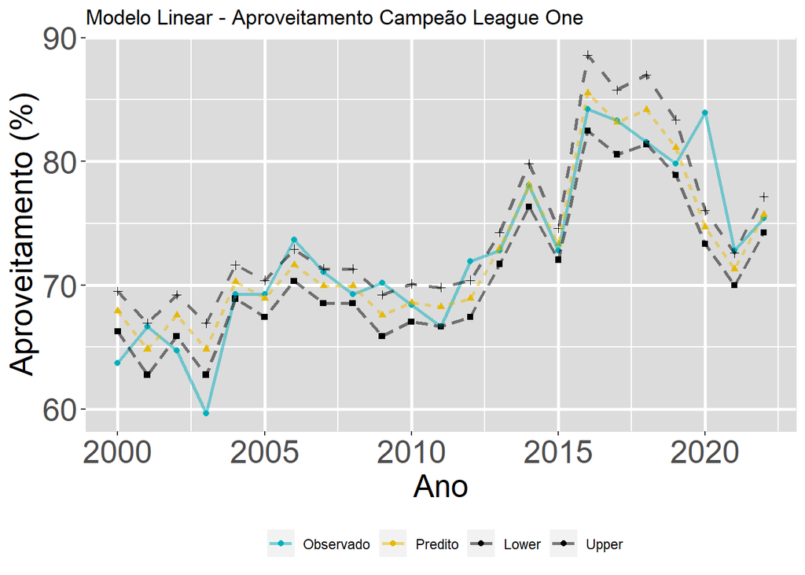

```r
mPred = data.frame(Obs = dadosLigue1$ano,
                   Observado = dados_regressao_Ligue1$aproveitamento,
                   Predito = dados_predicoes_ic_league_one[,1],
                   Lower = dados_predicoes_ic_league_one[,2],
                   Upper = dados_predicoes_ic_league_one[,3]
                   )

mPred2 = reshape2::melt(mPred, id = "Obs")

ggplot(mPred2, aes(x = Obs, y = value, group = variable)) +
  geom_point(aes(shape = variable, color = variable),
             size = 1.5) +
  geom_line(aes(linetype = variable, color = variable),
            size = 0.9, alpha = 0.5) +
  scale_color_manual(name = "", values = c("#00AFBB", "#E7B800", "black", "black")) +
  guides(shape = "none", linetype = "none") +
  labs(x = "Ano",
       y = "Aproveitamento (%)",
       title = "Modelo Linear - Aproveitamento Campeão League One") +
  theme(legend.title = element_blank(),
        legend.position = "bottom",
        axis.text = element_text(size = 20),
        axis.title = element_text(size = 20),
        panel.background = element_rect(fill = "#DCDCDC",
                                        colour = "#DCDCDC",
                                        size = 0.5, linetype = "solid"),
        panel.grid.major = element_line(size = 0.9, linetype = 'solid',
                                        colour = "white"),
        panel.grid.minor = element_line(size = 0.5, linetype = 'solid',
                                        colour = "white"))
```

# Comparação de resultados

Ou seja, para os dois modelos os coeficientes foram muito semelhantes em relação ao saldo de gols.

Além disso, tivemos um resultado, pelo $R^2$ ajustado melhor para o caso da Ligue1 onde:

- $R^2$ ajustado LaLiga: $78,95\%$
- $R^2$ ajustado Ligue1: $80,92\%$

A partir das visuzalições vemos também que o modelo se ajustou melhor no caso da Ligue1, onde os valores observados estiveram, na maior parte das vezes, dentro do intervalo de predição.